In cource of the project we are going to analyse a list of hypotheses and results of A/B testing.  
In the Part 1 of the project we will range the hypothesis that may help boost revenue of a big online store. To do this we will look into data that is stored in the "hypotheses" table and set priority to every hypothesis using different appoaches (ICE and RICE).  
Next in the Part 2 of the Project we are going to analyse A/B test results that were collected duting 1-month experiment. We are going to look into the data stored in 2 tables: orders_us and visits_us. For the purpose of analysis we are going to split the collected data in 2 equal groups and calculate statistical significane of the difference in orders size and in conversion rates. This way we are going to check if the difference in the key metrics of these groups is due to random chance or it is due to the treatment.  
In the end we are going to make conclusions if the experiment was a success, should we continue collecting data or should we stop it.

# Table of contents:

Part 1. Prioritizing Hypotheses  
Part 2. A/B Test Analysis  
Data Study  
1. Cumulative revenue by group  
2. Cumulative average order size by group  
3. Relative difference in cumulative average order size for group B compared with group A  
4. Conversion rate  
5. Scatter chart of the number of orders per user  
6. 95th and 99th percentiles for the number of orders per user  
7. Scatter chart of order prices  
8. 95th and 99th percentiles of order prices  
9. Statistical significance of the difference in conversion between the groups using the raw data  
10. Statistical significance of the difference in average order size between the groups using the raw data  
11. Statistical significance of the difference in conversion between the groups using the filtered data  
12. Statistical significance of the difference in average order size between the groups using the filtered data  
13. Decision based on the test results

```python
import pandas as pd
import plotly.express as px
import matplotlib.pyplot as plt
import numpy as np
from scipy import stats as st
import numpy
import seaborn as sns
from IPython.display import display

hypotheses = pd.read_csv('./hypotheses_us.csv', sep=';')
```

# Part 1. Prioritizing Hypotheses

# Data study

```python
display(hypotheses)
```

|  | Hypothesis | Reach | Impact | Confidence | Effort |
| --- | --- | --- | --- | --- | --- |
| 0 | Add two new channels for attracting traffic. T... | 3 | 10 | 8 | 6 |
| 1 | Launch your own delivery service. This will sh... | 2 | 5 | 4 | 10 |
| 2 | Add product recommendation blocks to the store... | 8 | 3 | 7 | 3 |
| 3 | Change the category structure. This will incre... | 8 | 3 | 3 | 8 |
| 4 | Change the background color on the main page. ... | 3 | 1 | 1 | 1 |
| 5 | Add a customer review page. This will increase... | 3 | 2 | 2 | 3 |
| 6 | Show banners with current offers and sales on ... | 5 | 3 | 8 | 3 |
| 7 | Add a subscription form to all the main pages.... | 10 | 7 | 8 | 5 |
| 8 | Launch a promotion that gives users discounts ... | 1 | 9 | 9 | 5 |

```python
#lowercase to all column names of hypotheses df
hypotheses.columns = map(str.lower, hypotheses.columns)
```

```python
hypotheses.info()
```

```
<class 'pandas.core.frame.DataFrame'>
RangeIndex: 9 entries, 0 to 8
Data columns (total 5 columns):
 #   Column      Non-Null Count  Dtype
---  ------      --------------  -----
 0   hypothesis  9 non-null      object
 1   reach       9 non-null      int64
 2   impact      9 non-null      int64
 3   confidence  9 non-null      int64
 4   effort      9 non-null      int64
dtypes: int64(4), object(1)
memory usage: 388.0+ bytes
```

```python
hypotheses['hypothesis'].value_counts()
```

```
Change the background color on the main page. This will increase user engagement                                          1
Launch your own delivery service. This will shorten delivery time                                                         1
Change the category structure. This will increase conversion since users will find the products they want more quickly    1
Add product recommendation blocks to the store's site. This will increase conversion and average purchase size            1
Add two new channels for attracting traffic. This will bring 30% more users                                               1
Add a subscription form to all the main pages. This will help you compile a mailing list                                  1
Launch a promotion that gives users discounts on their birthdays                                                          1
Add a customer review page. This will increase the number of orders                                                       1
Show banners with current offers and sales on the main page. This will boost conversion                                   1
Name: hypothesis, dtype: int64
```

# Hypotheses ranging

### ICE framework

We are going to calculate ICE score the following way: (impact * confidence)/effort

```python
#adding the ICE column to the table:
hypotheses['ICE'] = (hypotheses['impact']*hypotheses['confidence'])/hypotheses['effort']

#printing the result:
print(hypotheses[['hypothesis','ICE']].sort_values(by='ICE', ascending=False))
```

```
                                          hypothesis        ICE
8  Launch a promotion that gives users discounts ...  16.200000
0  Add two new channels for attracting traffic. T...  13.333333
7  Add a subscription form to all the main pages....  11.200000
6  Show banners with current offers and sales on ...   8.000000
2  Add product recommendation blocks to the store...   7.000000
1  Launch your own delivery service. This will sh...   2.000000
5  Add a customer review page. This will increase...   1.333333
3  Change the category structure. This will incre...   1.125000
4  Change the background color on the main page. ...   1.000000
```

According to the ICE framework the most highly ranked hypothesis are no. 8 and 0: "Launch a promotion that gives users discounts on their birthdays" and "Add two new channels for attracting traffic. This will bring 30% more users".

### RICE framework

This method is helpful if it’s important to understand how many of our customers a given feature will benefit. We are going to calculate RICE score the following way:

RICE score = (reach*impact*confidence)/effort

```python
#adding the RICE column to the table:
hypotheses['RICE'] = (hypotheses['reach']*hypotheses['impact']*hypotheses['confidence'])/hypotheses['effort']

#printing the result:
print(hypotheses[['hypothesis','RICE']].sort_values(by='RICE', ascending=False))
```

```
                                          hypothesis   RICE
7  Add a subscription form to all the main pages....  112.0
2  Add product recommendation blocks to the store...   56.0
0  Add two new channels for attracting traffic. T...   40.0
6  Show banners with current offers and sales on ...   40.0
8  Launch a promotion that gives users discounts ...   16.2
3  Change the category structure. This will incre...    9.0
1  Launch your own delivery service. This will sh...    4.0
5  Add a customer review page. This will increase...    4.0
4  Change the background color on the main page. ...    3.0
```

Taking into account reach factor has changed the ranking dramatically. Now the top priority hypothesis are no. 7 and 2: "Add a subscription form to all the main pages. This will help you compile a mailing list" and "Add product recommendation blocks to the store's site. This will increase conversion and average purchase size".

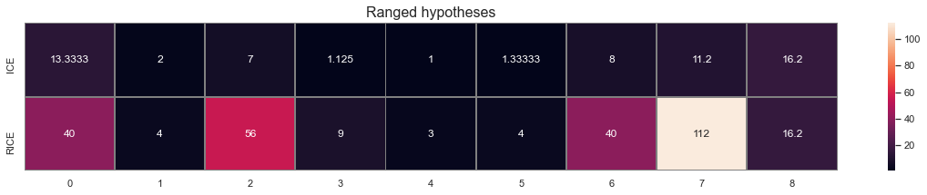

```python
#heat map for the ranged hypothesis:
hypotheses_ranged = hypotheses.drop(['hypothesis','reach', 'impact', 'confidence', 'effort'], axis=1)
sns.set(style='white')
plt.figure(figsize=(20, 3))
plt.title('Ranged hypotheses', fontsize =16)
sns.heatmap(hypotheses_ranged.T, annot=True, fmt='g', linewidths=1, linecolor='grey');
```

Hypotheses ranging looks different for the two frameworks. If we want to take into consideration as many factors as possible we should start testing the RICE top ranked hypotheses: no. 7, 2, 0, 6. This way we will prioritize the hypotheses that are going to reach the maximum number of customers.

# Part 2. A/B Test Analysis

# Data study

```python
#adjustments of the paths for the Practicum platform:
#orders = pd.read_csv('/datasets/orders_us.csv', sep=',')
#visits = pd.read_csv('/datasets/visits_us.csv', sep=',')
orders = pd.read_csv('./orders_us.csv', sep=',')
visits = pd.read_csv('./visits_us.csv', sep=',')
```

```python
display(orders)
```

|  | transactionId | visitorId | date | revenue | group |
| --- | --- | --- | --- | --- | --- |
| 0 | 3667963787 | 3312258926 | 2019-08-15 | 30.4 | B |
| 1 | 2804400009 | 3642806036 | 2019-08-15 | 15.2 | B |
| 2 | 2961555356 | 4069496402 | 2019-08-15 | 10.2 | A |
| 3 | 3797467345 | 1196621759 | 2019-08-15 | 155.1 | B |
| 4 | 2282983706 | 2322279887 | 2019-08-15 | 40.5 | B |
| ... | ... | ... | ... | ... | ... |
| 1192 | 2662137336 | 3733762160 | 2019-08-14 | 100.8 | B |
| 1193 | 2203539145 | 370388673 | 2019-08-14 | 50.1 | A |
| 1194 | 1807773912 | 573423106 | 2019-08-14 | 165.3 | A |
| 1195 | 1947021204 | 1614305549 | 2019-08-14 | 5.5 | A |
| 1196 | 3936777065 | 2108080724 | 2019-08-15 | 3120.1 | B |

1197 rows × 5 columns

```python
orders.info()
```

```
<class 'pandas.core.frame.DataFrame'>
RangeIndex: 1197 entries, 0 to 1196
Data columns (total 5 columns):
 #   Column         Non-Null Count  Dtype
---  ------         --------------  -----
 0   transactionId  1197 non-null   int64
 1   visitorId      1197 non-null   int64
 2   date           1197 non-null   object
 3   revenue        1197 non-null   float64
 4   group          1197 non-null   object
dtypes: float64(1), int64(2), object(2)
memory usage: 37.5+ KB
```

```python
#changing the date type
orders['date'] = pd.to_datetime(orders['date'], format="%Y.%m.%d")
```

```python
#checking if there are visitors that got to both groups, A and B

visitors_groups = orders.groupby('visitorId', as_index=False).agg({'group' : pd.Series.nunique})
visitors_duplicated = visitors_groups.query('group>1')
visitors_duplicated['visitorId'].count()
```

```
58
```

We have 58 visitors that got to both groups. We will exclude them from our db (as according to the A/B testing rules users can’t take a part in 2 groups) and then we will form equal groups A and B with random sample method.

```python
#excluding visitors that got to 2 groups:

orders_filtered = orders.query('visitorId not in @visitors_duplicated.visitorId')
display(orders_filtered)
```

|  | transactionId | visitorId | date | revenue | group |
| --- | --- | --- | --- | --- | --- |
| 0 | 3667963787 | 3312258926 | 2019-08-15 | 30.4 | B |
| 1 | 2804400009 | 3642806036 | 2019-08-15 | 15.2 | B |
| 3 | 3797467345 | 1196621759 | 2019-08-15 | 155.1 | B |
| 4 | 2282983706 | 2322279887 | 2019-08-15 | 40.5 | B |
| 5 | 182168103 | 935554773 | 2019-08-15 | 35.0 | B |
| ... | ... | ... | ... | ... | ... |
| 1191 | 3592955527 | 608641596 | 2019-08-14 | 255.7 | B |
| 1192 | 2662137336 | 3733762160 | 2019-08-14 | 100.8 | B |
| 1193 | 2203539145 | 370388673 | 2019-08-14 | 50.1 | A |
| 1194 | 1807773912 | 573423106 | 2019-08-14 | 165.3 | A |
| 1196 | 3936777065 | 2108080724 | 2019-08-15 | 3120.1 | B |

1016 rows × 5 columns

```python
visitorsA = orders_filtered.query('group=="A"')
display(visitorsA)
```

|  | transactionId | visitorId | date | revenue | group |
| --- | --- | --- | --- | --- | --- |
| 7 | 2626614568 | 78758296 | 2019-08-15 | 20.1 | A |
| 8 | 1576988021 | 295230930 | 2019-08-15 | 215.9 | A |
| 10 | 3649131742 | 879864040 | 2019-08-15 | 65.7 | A |
| 12 | 2809384911 | 3213223594 | 2019-08-15 | 115.4 | A |
| 14 | 3859315276 | 1565034404 | 2019-08-15 | 170.9 | A |
| ... | ... | ... | ... | ... | ... |
| 1185 | 948555526 | 2710193528 | 2019-08-14 | 15.2 | A |
| 1187 | 2274188238 | 132143192 | 2019-08-14 | 15.5 | A |
| 1188 | 1692103379 | 1022829655 | 2019-08-14 | 5.7 | A |
| 1193 | 2203539145 | 370388673 | 2019-08-14 | 50.1 | A |
| 1194 | 1807773912 | 573423106 | 2019-08-14 | 165.3 | A |

468 rows × 5 columns

```python
visitorsA['visitorId'].nunique()
```

```
445
```

```python
visitorsB_raw = orders_filtered.query('group=="B"')
display(visitorsB_raw)
```

|  | transactionId | visitorId | date | revenue | group |
| --- | --- | --- | --- | --- | --- |
| 0 | 3667963787 | 3312258926 | 2019-08-15 | 30.4 | B |
| 1 | 2804400009 | 3642806036 | 2019-08-15 | 15.2 | B |
| 3 | 3797467345 | 1196621759 | 2019-08-15 | 155.1 | B |
| 4 | 2282983706 | 2322279887 | 2019-08-15 | 40.5 | B |
| 5 | 182168103 | 935554773 | 2019-08-15 | 35.0 | B |
| ... | ... | ... | ... | ... | ... |
| 1186 | 2116724386 | 2146711261 | 2019-08-14 | 240.6 | B |
| 1190 | 38478481 | 1197745035 | 2019-08-14 | 135.3 | B |
| 1191 | 3592955527 | 608641596 | 2019-08-14 | 255.7 | B |
| 1192 | 2662137336 | 3733762160 | 2019-08-14 | 100.8 | B |
| 1196 | 3936777065 | 2108080724 | 2019-08-15 | 3120.1 | B |

548 rows × 5 columns

```python
visitorsB_raw['visitorId'].nunique()
```

```
528
```

As group B bigger than group A(445 vs 528 unique visitors), we will randomly pick up from this initial group the same number of visitors as in group A (=445).

```python
import random
visitorsB_raw_ID = visitorsB_raw['visitorId'].values.tolist()
visitorsB_ID = random.sample(visitorsB_raw_ID, k=445)

display(visitorsB_ID) #we got list of 445 unique visitors IDs for group B
```

[output not shown]

[output cut: 390 more lines]

[output not shown]

```python
#setting a df with visitors from group B equal to group A

visitorsB = visitorsB_raw.query('visitorId == @visitorsB_ID')
display(visitorsB)
```

|  | transactionId | visitorId | date | revenue | group |
| --- | --- | --- | --- | --- | --- |
| 0 | 3667963787 | 3312258926 | 2019-08-15 | 30.4 | B |
| 1 | 2804400009 | 3642806036 | 2019-08-15 | 15.2 | B |
| 3 | 3797467345 | 1196621759 | 2019-08-15 | 155.1 | B |
| 5 | 182168103 | 935554773 | 2019-08-15 | 35.0 | B |
| 6 | 398296753 | 2900797465 | 2019-08-15 | 30.6 | B |
| ... | ... | ... | ... | ... | ... |
| 1186 | 2116724386 | 2146711261 | 2019-08-14 | 240.6 | B |
| 1190 | 38478481 | 1197745035 | 2019-08-14 | 135.3 | B |
| 1191 | 3592955527 | 608641596 | 2019-08-14 | 255.7 | B |
| 1192 | 2662137336 | 3733762160 | 2019-08-14 | 100.8 | B |
| 1196 | 3936777065 | 2108080724 | 2019-08-15 | 3120.1 | B |

451 rows × 5 columns

```python
#joining the two tables with A visitors and B visitors together
frames = [visitorsA, visitorsB]
orders_filtered = pd.concat(frames)
orders_filtered
```

|  | transactionId | visitorId | date | revenue | group |
| --- | --- | --- | --- | --- | --- |
| 7 | 2626614568 | 78758296 | 2019-08-15 | 20.1 | A |
| 8 | 1576988021 | 295230930 | 2019-08-15 | 215.9 | A |
| 10 | 3649131742 | 879864040 | 2019-08-15 | 65.7 | A |
| 12 | 2809384911 | 3213223594 | 2019-08-15 | 115.4 | A |
| 14 | 3859315276 | 1565034404 | 2019-08-15 | 170.9 | A |
| ... | ... | ... | ... | ... | ... |
| 1186 | 2116724386 | 2146711261 | 2019-08-14 | 240.6 | B |
| 1190 | 38478481 | 1197745035 | 2019-08-14 | 135.3 | B |
| 1191 | 3592955527 | 608641596 | 2019-08-14 | 255.7 | B |
| 1192 | 2662137336 | 3733762160 | 2019-08-14 | 100.8 | B |
| 1196 | 3936777065 | 2108080724 | 2019-08-15 | 3120.1 | B |

919 rows × 5 columns

```python
#moving on to "visits" df:
display(visits)
```

|  | date | group | visits |
| --- | --- | --- | --- |
| 0 | 2019-08-01 | A | 719 |
| 1 | 2019-08-02 | A | 619 |
| 2 | 2019-08-03 | A | 507 |
| 3 | 2019-08-04 | A | 717 |
| 4 | 2019-08-05 | A | 756 |
| ... | ... | ... | ... |
| 57 | 2019-08-27 | B | 720 |
| 58 | 2019-08-28 | B | 654 |
| 59 | 2019-08-29 | B | 531 |
| 60 | 2019-08-30 | B | 490 |
| 61 | 2019-08-31 | B | 718 |

62 rows × 3 columns

```python
visits.info()
```

```
<class 'pandas.core.frame.DataFrame'>
RangeIndex: 62 entries, 0 to 61
Data columns (total 3 columns):
 #   Column  Non-Null Count  Dtype
---  ------  --------------  -----
 0   date    62 non-null     object
 1   group   62 non-null     object
 2   visits  62 non-null     int64
dtypes: int64(1), object(2)
memory usage: 1.0+ KB
```

```python
#changing the date type
visits['date'] = pd.to_datetime(visits['date'], format="%Y.%m.%d")
```

# Results study

## 1. Cumulative revenue by group

We are going to graph cumulative revenue by group and make conclusions.

```python
# building an array with unique paired date-group values
datesGroups = orders_filtered[['date','group']].drop_duplicates()
display(datesGroups)
```

|  | date | group |
| --- | --- | --- |
| 7 | 2019-08-15 | A |
| 45 | 2019-08-16 | A |
| 55 | 2019-08-01 | A |
| 86 | 2019-08-22 | A |
| 124 | 2019-08-17 | A |
| ... | ... | ... |
| 930 | 2019-08-31 | B |
| 1043 | 2019-08-11 | B |
| 1067 | 2019-08-12 | B |
| 1114 | 2019-08-13 | B |
| 1149 | 2019-08-14 | B |

62 rows × 2 columns

```python
# getting aggregated cumulative daily data on orders revenue
ordersAggregated = datesGroups.apply(lambda x: orders_filtered[np.logical_and(orders_filtered['date'] <= x['date'], orders_filtered['group'] == x['group'])].agg({'date' : 'max', 'group' : 'max', 'transactionId' : pd.Series.nunique, 'visitorId' : pd.Series.nunique, 'revenue' : 'sum'}), axis=1).sort_values(by=['date','group'])
ordersAggregated.head()
```

|  | date | group | transactionId | visitorId | revenue |
| --- | --- | --- | --- | --- | --- |
| 55 | 2019-08-01 | A | 23 | 19 | 2266.6 |
| 66 | 2019-08-01 | B | 12 | 12 | 650.6 |
| 175 | 2019-08-02 | A | 42 | 36 | 3734.9 |
| 173 | 2019-08-02 | B | 31 | 30 | 2772.6 |
| 291 | 2019-08-03 | A | 66 | 60 | 5550.1 |

```python
# getting aggregated cumulative daily data on visits
#the number of distinct visits in the test group up to the specified date, inclusive
visitsAggregated = datesGroups.apply(lambda x: visits[np.logical_and(visits['date'] <= x['date'], visits['group'] == x['group'])].agg({'date' : 'max', 'group' : 'max', 'visits' : 'sum'}), axis=1).sort_values(by=['date','group'])
visitsAggregated.head()
```

|  | date | group | visits |
| --- | --- | --- | --- |
| 55 | 2019-08-01 | A | 719 |
| 66 | 2019-08-01 | B | 713 |
| 175 | 2019-08-02 | A | 1338 |
| 173 | 2019-08-02 | B | 1294 |
| 291 | 2019-08-03 | A | 1845 |

```python
# merging the two tables into one and giving its columns descriptive names
cumulativeData = ordersAggregated.merge(visitsAggregated, left_on=['date', 'group'], right_on=['date', 'group'])
cumulativeData.columns = ['date', 'group', 'orders', 'buyers', 'revenue', 'visits']

print(cumulativeData.head(5))
```

```
        date group  orders  buyers  revenue  visits
0 2019-08-01     A      23      19   2266.6     719
1 2019-08-01     B      12      12    650.6     713
2 2019-08-02     A      42      36   3734.9    1338
3 2019-08-02     B      31      30   2772.6    1294
4 2019-08-03     A      66      60   5550.1    1845
```

We have received cumulative data on revenue per day per every group. Now we are goinug to visualize it for further analysis.

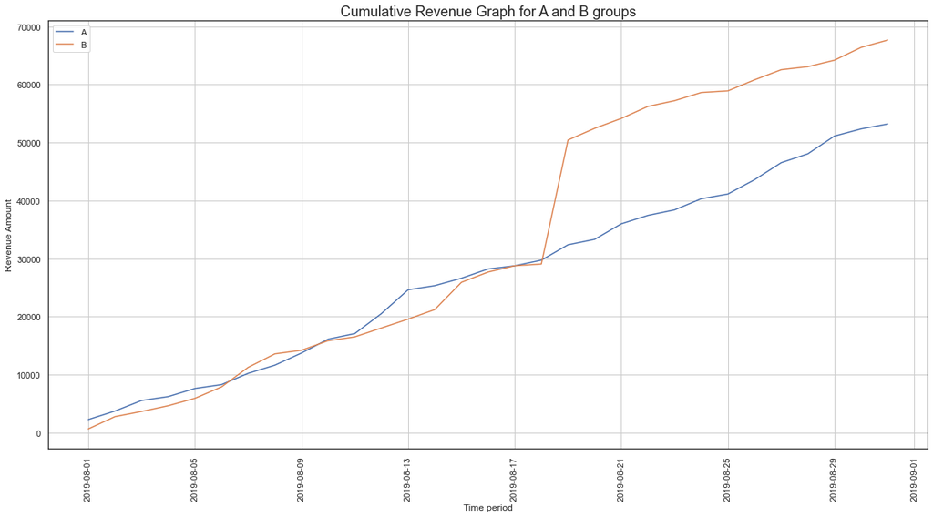

```python
# DataFrame with cumulative orders and cumulative revenue by day, group A
cumulativeRevenueA = cumulativeData[cumulativeData['group']=='A'][['date','revenue', 'orders']]

# DataFrame with cumulative orders and cumulative revenue by day, group B
cumulativeRevenueB = cumulativeData[cumulativeData['group']=='B'][['date','revenue', 'orders']]

# Plotting the group A revenue graph
plt.figure(figsize=(20,10))
plt.plot(cumulativeRevenueA['date'], cumulativeRevenueA['revenue'], label='A')

# Plotting the group B revenue graph
plt.plot(cumulativeRevenueB['date'], cumulativeRevenueB['revenue'], label='B')

plt.xticks(rotation=90)
plt.title('Cumulative Revenue Graph for A and B groups', fontsize=18)
plt.xlabel('Time period', fontsize=12)
plt.ylabel('Revenue Amount', fontsize=12)
plt.grid()
plt.legend()
plt.show()
```

## 2. Cumulative average order size by group

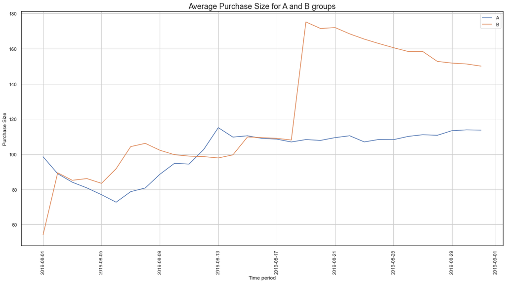

```python
#We will plot average purchase size by groups. We'll divide cumulative revenue by the cumulative number of orders:
plt.figure(figsize=(20,10))
plt.plot(cumulativeRevenueA['date'], cumulativeRevenueA['revenue']/cumulativeRevenueA['orders'], label='A')
plt.plot(cumulativeRevenueB['date'], cumulativeRevenueB['revenue']/cumulativeRevenueB['orders'], label='B')

plt.xticks(rotation=90)

plt.title('Average Purchase Size for A and B groups', fontsize=18)
plt.xlabel('Time period', fontsize=12)
plt.ylabel('Purchase Size', fontsize=12)
plt.grid()
plt.legend()
plt.show()
```

## 3. Relative difference in cumulative average order size for group B compared with group A.

We will plot a relative difference graph for the average purchase sizes. To do this we will form a new data frame with cumulative revenue for both groups merging two tables. Relative difference will be calculated as ratio between cumulative average order size of group B and group A.  
We'll add a horizontal axis where ratio equals to zero (values of both groups are equal).

### pic 1

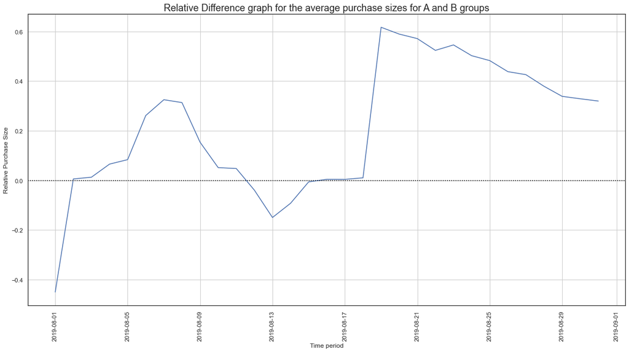

```python
# gathering the data into one DataFrame
mergedCumulativeRevenue = cumulativeRevenueA.merge(cumulativeRevenueB, left_on='date', right_on='date', how='left', suffixes=['A', 'B'])

# plotting a relative difference graph for the average purchase sizes
plt.figure(figsize=(20,10))
plt.plot(mergedCumulativeRevenue['date'], (mergedCumulativeRevenue['revenueB']/mergedCumulativeRevenue['ordersB'])/(mergedCumulativeRevenue['revenueA']/mergedCumulativeRevenue['ordersA'])-1)
plt.xticks(rotation=90)
plt.grid()
# adding the X axis
plt.axhline(y=0, color='black', linestyle=':')

plt.title('Relative Difference graph for the average purchase sizes for A and B groups', fontsize=18)
plt.xlabel('Time period', fontsize=12)
plt.ylabel('Relative Purchase Size', fontsize=12)

plt.show()
```

## 4. Conversion rate per group

We will calculate conversion rate as the ratio of orders to the number of visits for each day. Next we will plot it.

```python
#checking the date range:
mergedCumulativeRevenue['date'].describe()
```

```
count                      31
unique                     31
top       2019-08-02 00:00:00
freq                        1
first     2019-08-01 00:00:00
last      2019-08-31 00:00:00
Name: date, dtype: object
```

We will calculate cumulative conversion and then a relative difference for the cumulative conversion rates

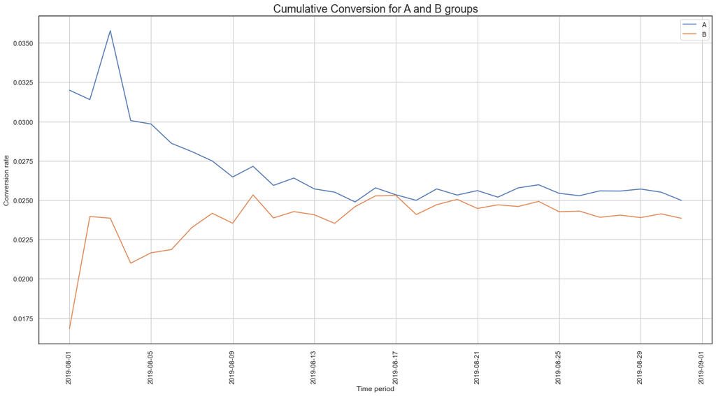

```python
#calculating cumulative conversion as the ratio of orders to the number of visits for each day
cumulativeData['conversion'] = cumulativeData['orders']/cumulativeData['visits']

# selecting data on group A
cumulativeDataA = cumulativeData[cumulativeData['group']=='A']

# selecting data on group B
cumulativeDataB = cumulativeData[cumulativeData['group']=='B']

# plotting the graphs
plt.figure(figsize=(20,10))
plt.plot(cumulativeDataA['date'], cumulativeDataA['conversion'], label='A')
plt.plot(cumulativeDataB['date'], cumulativeDataB['conversion'], label='B')
plt.legend()

plt.xticks(rotation=90)
#plt.axis(['2019-08-01', '2019-08-31', 0, 0.015])
plt.grid()


plt.title('Cumulative Conversion for A and B groups', fontsize=18)
plt.xlabel('Time period', fontsize=12)
plt.ylabel('Conversion rate', fontsize=12)
plt.show()
```

The chart demonstrates that group A had much better conversion rate at the start of experiment (0.032 vs 0.02) but then it dropped significatly and the difference was not so dramatic afterwards. Fluctuations in conversion of one group corresponded with fluctuations of the second group, they had peaks and troughs at the same dates. Fluctuations eased by the end of experiment for both groups, the difference in conversion rates was not big but stable.

### pic 2

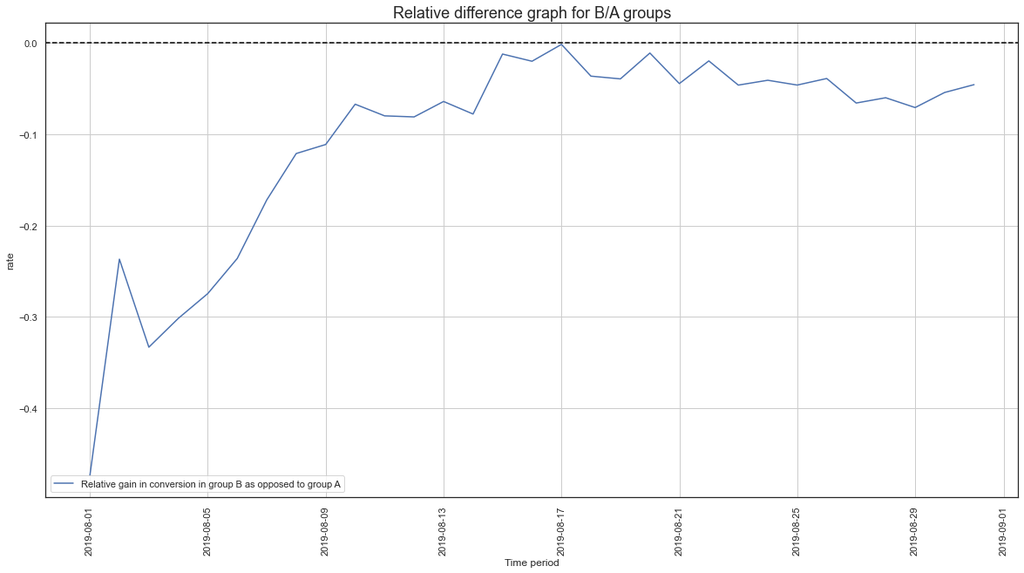

```python
#plotting a relative difference graph for the cumulative conversion rates B/A:
mergedCumulativeConversions = cumulativeDataA[['date','conversion']].merge(cumulativeDataB[['date','conversion']], left_on='date', right_on='date', how='left', suffixes=['A', 'B'])
plt.figure(figsize=(20,10))
plt.plot(mergedCumulativeConversions['date'], mergedCumulativeConversions['conversionB']/mergedCumulativeConversions['conversionA']-1, label="Relative gain in conversion in group B as opposed to group A")
plt.legend()

plt.axhline(y=0, color='black', linestyle='--')
#plt.axhline(y=-0.1, color='grey', linestyle='--')
#plt.axis(["2019-08-01", '2019-08-31', -0.6, 0.6])

plt.xticks(rotation=90)
plt.grid()

plt.title('Relative difference graph for B/A groups', fontsize=18)
plt.xlabel('Time period', fontsize=12)
plt.ylabel('rate', fontsize=12)
plt.show()
```

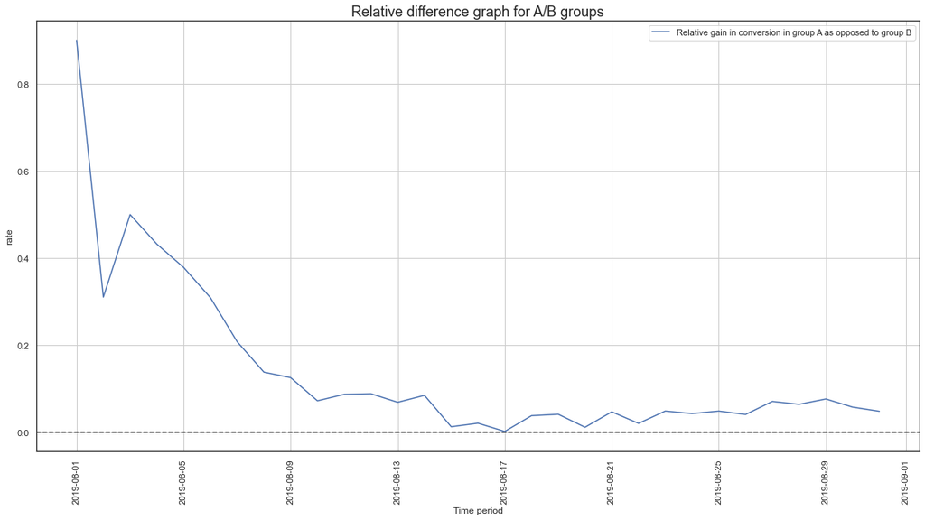

```python
#plotting a relative difference graph for the cumulative conversion rates A/B:
plt.figure(figsize=(20,10))
plt.plot(mergedCumulativeConversions['date'], mergedCumulativeConversions['conversionA']/mergedCumulativeConversions['conversionB']-1, label="Relative gain in conversion in group A as opposed to group B")
plt.legend()

plt.axhline(y=0, color='black', linestyle='--')
#plt.axhline(y=-0.1, color='grey', linestyle='--')
#plt.axis(["2019-08-01", '2019-08-31', -0.6, 0.6])

plt.xticks(rotation=90)
plt.grid()

plt.title('Relative difference graph for A/B groups', fontsize=18)
plt.xlabel('Time period', fontsize=12)
plt.ylabel('rate', fontsize=12)
plt.show()
```

These charts prove that conversion of group A surpasses the one of group B. Although the differece eased during the month of experiment it is still 5% higher for group A.

## 5. Number of orders per user

```python
#creating a table with data on users and orders
ordersByUsers = orders_filtered.drop(['group', 'revenue', 'date'], axis=1).groupby('visitorId', as_index=False).agg({'transactionId' : pd.Series.nunique})
ordersByUsers.columns = ['visitorId','orders']
print(ordersByUsers.sort_values(by='orders',ascending=False).head(10))
```

```
      visitorId  orders
820  3967698036       3
122   611059232       3
803  3908431265       3
424  2108163459       3
617  2988190573       3
44    249864742       3
564  2742574263       3
363  1772171838       2
846  4109358064       2
102   522292794       2
```

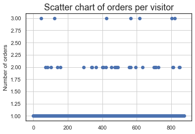

```python
#plotting chart
x_values = pd.Series(range(0, len(ordersByUsers)))
plt.scatter(x_values, ordersByUsers['orders'])
plt.title('Scatter chart of orders per visitor', fontsize=18)

plt.ylabel('Number of orders', fontsize=12)

plt.grid()
plt.show()
```

Most of the visitors made 1 order, just few of them made 2 and only several made 3 orders. To define the share of outliers we will calculate percentiles below.

Now we will look at the number of orders per buyer for every group and it's dynamics.

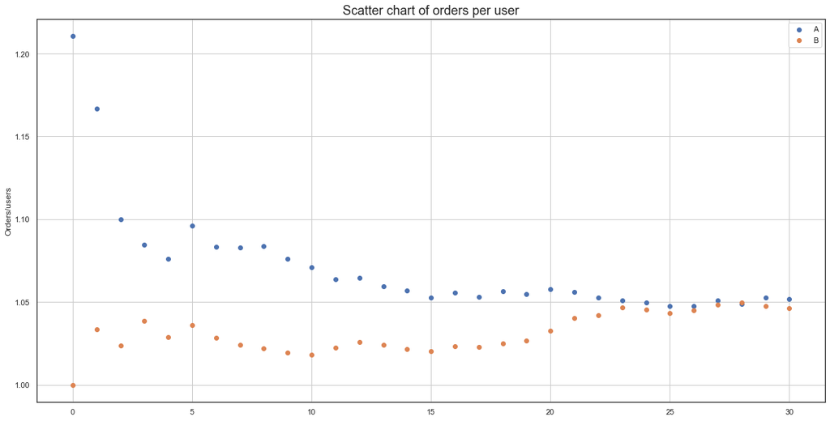

```python
#calculating cumulative conversion as the ratio of orders to the number of visits for each day
cumulativeData['orders_per_users'] = cumulativeData['orders']/cumulativeData['buyers']

# selecting data on group A
cumulativeDataA = cumulativeData[cumulativeData['group']=='A']

# selecting data on group B
cumulativeDataB = cumulativeData[cumulativeData['group']=='B']

# plotting the scatter chart
plt.figure(figsize=(20,10))
x_values = pd.Series(range(0, len(cumulativeDataA['orders_per_users'])))
plt.scatter(x_values, cumulativeDataA['orders_per_users'], label='A')
plt.scatter(x_values, cumulativeDataB['orders_per_users'], label='B')
plt.title('Scatter chart of orders per user', fontsize=18)

plt.ylabel('Orders/users', fontsize=12)
plt.legend()

plt.grid()
plt.show()
```

At the beginning group A got 20% more orders per buyer; by the 23rd day of experiment the values stabilized around 1.05 orders per buyer for both groups.

## 6. 95th and 99th percentiles for the number of orders per user. Defining point of anomaly.

```python
#Calculate the 95th and 99th percentiles for the number of orders per user.
np.percentile(ordersByUsers['orders'], [95, 99])
```

```
array([1., 2.])
```

```python
#setting a variable for further calculations
too_many = int(np.percentile(ordersByUsers['orders'], [99]))
too_many
```

```
2
```

Not more than 5% of users placed more than 1 order, and not more than 1% of users made more than two orders. According to these calculations we can say that we have defined the point at which a data point becomes an anomaly: visitors with 3 orders per capita are outliers.

## 7. Plot a scatter chart of order prices

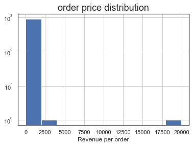

```python
#histogram of order price distribution
plt.hist(orders_filtered['revenue'], log=True)
plt.title('order price distribution', fontsize=18)
plt.xlabel('Revenue per order', fontsize=12)
plt.grid()
plt.show()
```

We can see that most of the orders bring up to 1500. Still there are some outliers with revenue over 3000. To investigate it we will buld scatter plot.

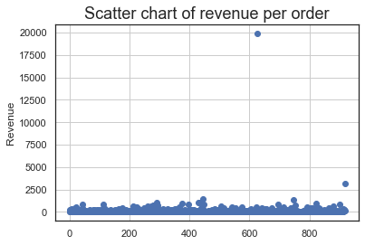

```python
#another chart to evaluate order prices:
x_values = pd.Series(range(0, len(orders_filtered['revenue'])))
plt.scatter(x_values, orders_filtered['revenue'])
plt.title('Scatter chart of revenue per order', fontsize=18)

plt.ylabel('Revenue', fontsize=12)

plt.grid()
plt.show()
```

The second chart proves that there are only several orders with revenue over 1000. They can be stated as outliers. In order to state the upper fence more precisely we will calculate the percentiles as well.

## 8. 95th and 99th percentiles of order prices. Point of anomaly.

```python
#Calculatinug the 95th and 99th percentiles for the order prices.
np.percentile(orders_filtered['revenue'], [95, 99])
```

```
array([410.5, 830.3])
```

```python
#setting a variable for further calculations
too_expencive = int(np.percentile(orders_filtered['revenue'], [99]))
too_expencive
```

```
830
```

## 9. Statistical significance of the difference in conversion between the groups using the raw data.

We are going to calculate statistical significance of the difference in conversion between the groups using the Mann-Whitney U test because we have independent data samples with quantative variables (nonparametric version of the Student t-test), also the data doesn't follow normal distribution. We can see that the data is not normally distributed on a histogram here

We'll also find the relative difference in average order size between the groups:

```python
#splitting tables with data on two groups:
ordersByUsersA = orders_filtered[orders_filtered['group']=='A'].groupby('visitorId', as_index=False).agg({'transactionId' : pd.Series.nunique})
ordersByUsersA.columns = ['visitorId', 'orders']

ordersByUsersB = orders_filtered[orders_filtered['group']=='B'].groupby('visitorId', as_index=False).agg({'transactionId' : pd.Series.nunique})
ordersByUsersB.columns = ['visitorId', 'orders']
```

```python
#Combining the two tables with data on visits to form samples
sampleA = pd.concat([ordersByUsersA['orders'],pd.Series(0, index=np.arange(visits[visits['group']=='A']['visits'].sum() - len(ordersByUsersA['orders'])), name='orders')],axis=0)

sampleB = pd.concat([ordersByUsersB['orders'],pd.Series(0, index=np.arange(visits[visits['group']=='B']['visits'].sum() - len(ordersByUsersB['orders'])), name='orders')],axis=0)
```

Stating hypothesis:  
H0: there's not a statistically significant difference in conversion between the groups  
H1: average conversion level differs between the groups

A critical statistical significance level will be set at 0.05 as it is a commonly accepted one in the industry for non-multiple testing.

```python
alpha = .05

results =  st.mannwhitneyu(sampleA, sampleB)[1]

print("{0:.3f}".format(results))

if (results< alpha):
    print("We reject the null hypothesis")
else:
    print("We can't reject the null hypothesis")
```

```
0.267
We can't reject the null hypothesis
```

We have calculeted the p-value by implification of mannwhitneyu() criterion.  
We have received p-value greater than alfa thus with probability of 95% we cannot reject the null hypothesis and conclude that average conversion differs between the groups.

```python
# Calculating the relative conversion gain for group B/A:

print("{0:.3f}".format(sampleB.mean()/sampleA.mean()-1)) #the relative loss of group B
```

```
-0.045
```

## 10. Statistical significance of the difference in average order size between the groups using the raw data

To calculate the statistical significance of the difference in the segments' average order size, we'll pass the data on revenue to the mannwhitneyu() criterion. We'll also find the relative difference in average order size between the groups.

Stating hypothesis:  
H0: average order size between the groups is the same  
H1: average order size differs between the groups

A critical statistical significance level will be set to 0.05 as it is a commonly accepted one in the industry for non-multiple testing.

```python
alpha = .05

results =  st.mannwhitneyu(orders_filtered[orders_filtered['group']=='A']['revenue'], orders_filtered[orders_filtered['group']=='B']['revenue'])[1]

print("{0:.3f}".format(results))

if (results< alpha):
    print("We reject the null hypothesis")
else:
    print("We can't reject the null hypothesis")
```

```
0.158
We can't reject the null hypothesis
```

```python
#Calculating the relative difference in average order size between the groups (B/A):
print("{0:.3f}".format(orders_filtered[orders_filtered['group']=='B']['revenue'].mean()/orders_filtered[orders_filtered['group']=='A']['revenue'].mean()-1))
```

```
0.320
```

## 11. Statistical significance of the difference in conversion between the groups using the filtered data

In order to filter the data we will determine the outliers: IDs of the users that made too big or too expencive orders. Then we will filter them out from the raw data and calculate the statisical significance the same way as in pp.9.

```python
# we will find the ubnormal users' IDs:
# usrs that maid too many orders
usersWithManyOrders = pd.concat([ordersByUsersA[ordersByUsersA['orders'] > 2]['visitorId'], ordersByUsersB[ordersByUsersB['orders'] > 2]['visitorId']], axis = 0)
#users that paid too much
usersWithExpensiveOrders = orders_filtered.query('revenue > @too_expencive')['visitorId']
#joining the two groups together
abnormalUsers = pd.concat([usersWithManyOrders, usersWithExpensiveOrders], axis = 0).drop_duplicates().sort_values()
print(abnormalUsers.head(5))
print(abnormalUsers.shape) #defining total number of anomalous users.
```

```
1099    148427295
22      249864742
58      611059232
949     887908475
744     888512513
Name: visitorId, dtype: int64
(19,)
```

```python
#filtering out the abnormal users from the raw data:

sampleAFiltered = pd.concat([ordersByUsersA[np.logical_not(ordersByUsersA['visitorId'].isin(abnormalUsers))]['orders'],pd.Series(0, index=np.arange(visits[visits['group']=='A']['visits'].sum() - len(ordersByUsersA['orders'])),name='orders')],axis=0)

sampleBFiltered = pd.concat([ordersByUsersB[np.logical_not(ordersByUsersB['visitorId'].isin(abnormalUsers))]['orders'],pd.Series(0, index=np.arange(visits[visits['group']=='B']['visits'].sum() - len(ordersByUsersB['orders'])),name='orders')],axis=0)
```

```python
ordersByUsersA.head()
```

|  | visitorId | orders |
| --- | --- | --- |
| 0 | 11685486 | 1 |
| 1 | 54447517 | 1 |
| 2 | 66685450 | 1 |
| 3 | 78758296 | 1 |
| 4 | 85103373 | 1 |

```python
df_2=ordersByUsersA.head()
```

```python
df_2.head()
```

|  | visitorId | orders |
| --- | --- | --- |
| 0 | 11685486 | 1 |
| 1 | 54447517 | 1 |
| 2 | 66685450 | 1 |
| 3 | 78758296 | 1 |
| 4 | 85103373 | 1 |

```python
sampleAFiltered_2 = pd.concat([df_2[np.logical_not(ordersByUsersA['visitorId'].isin(abnormalUsers))]['orders'],pd.Series(0, index=np.arange(visits[visits['group']=='A']['visits'].sum() - len(df_2['orders'])),name='orders')],axis=0)
```

```python
sampleAFiltered_2.head(20)
```

```
0     1
1     1
2     1
3     1
4     1
0     0
1     0
2     0
3     0
4     0
5     0
6     0
7     0
8     0
9     0
10    0
11    0
12    0
13    0
14    0
Name: orders, dtype: int64
```

```python
visits.head()
```

|  | date | group | visits |
| --- | --- | --- | --- |
| 0 | 2019-08-01 | A | 719 |
| 1 | 2019-08-02 | A | 619 |
| 2 | 2019-08-03 | A | 507 |
| 3 | 2019-08-04 | A | 717 |
| 4 | 2019-08-05 | A | 756 |

```python
sampleAFiltered.head()
```

```
0    1
1    1
2    1
3    1
4    1
Name: orders, dtype: int64
```

```python
sampleBFiltered
```

```
0        1
1        1
2        1
3        1
4        1
        ..
18480    0
18481    0
18482    0
18483    0
18484    0
Name: orders, Length: 18909, dtype: int64
```

Now we will apply the statistical Mann-Whitney criterion to the resulting samples.

Keeping the same hypothesis and statistical significance level (0.05):  
H0: there's not a statistically significant difference in conversion between the groups  
H1: average conversion level differs between the groups

```python
alpha = .05

results =  st.mannwhitneyu(sampleAFiltered, sampleBFiltered)[1]

print("{0:.3f}".format(results))

if (results< alpha):
    print("We reject the null hypothesis")
else:
    print("We can't reject the null hypothesis")
```

```
0.325
We can't reject the null hypothesis
```

We got result that is very close to the previous one. For the data with filtered out outliers we still failed to reject the null hypothesis with the significance level of 5%.  
Therefore, we cannot make conclusion that conversion level for both groups is different.

```python
# Calculating the relative conversion gain for group B/A:

print("{0:.3f}".format(sampleBFiltered.mean()/sampleAFiltered.mean()-1)) #the relative loss of group B
```

```
-0.023
```

Thus for the filtered data we can't reject the null hypothesis that there's not a statistically significant difference in conversion between the groups. And the relative loss of group B is even less now, 2%.

## 12. Statistical significance of the difference in average order size between the groups using the filtered data.

Keeping stated hypothesis and significance level:  
H0: average order size between the groups is the same  
H1: average order size differs between the groups

```python
alpha = .05

results =  st.mannwhitneyu(orders_filtered[np.logical_and(
        orders_filtered['group']=='A',
        np.logical_not(orders_filtered['visitorId'].isin(abnormalUsers)))]['revenue'], orders_filtered[np.logical_and(
        orders_filtered['group']=='B',
        np.logical_not(orders_filtered['visitorId'].isin(abnormalUsers)))]['revenue'])[1]

print("{0:.3f}".format(results))

if (results< alpha):
    print("We reject the null hypothesis")
else:
    print("We can't reject the null hypothesis")
```

```
0.143
We can't reject the null hypothesis
```

Filtering out outliers almost hasn't changed the outcome here.

```python
#Calculating the relative difference in average order size between the groups (B/A):

print("{0:.3f}".format(
    orders_filtered[np.logical_and(orders_filtered['group']=='B',np.logical_not(orders_filtered['visitorId'].isin(abnormalUsers)))]['revenue'].mean()/
    orders_filtered[np.logical_and(
        orders_filtered['group']=='A',
        np.logical_not(orders_filtered['visitorId'].isin(abnormalUsers)))]['revenue'].mean() - 1))
```

```
-0.070
```

## 13. Making decision based on the test results. (The possible decisions are: 1. Stop the test, consider one of the groups the leader. 2. Stop the test, conclude that there is no difference between the groups. 3. Continue the test.)

- The graph showing the difference in conversion between the groups tells us that group B's results are worse and don't seem to be improving significantly (see the graph here [pic 2](#section_2)).